# Hamilton

Andrew Ba Tran

1/28/2017

# Visualizing Hamilton and musicals data

Let’s play around with this data set from the [Quartz article](https://qz.com/842610/broadways-race-problem-is-unmasked-by-data-but-the-theater-industry-is-still-stuck-in-neutral/) about race in musicals and plays on Broadway.

Bring in the data.

```r
broadway <- read.csv("data/broadway.csv", stringsAsFactors=F)
```

Let’s see if we can replicate this chart.

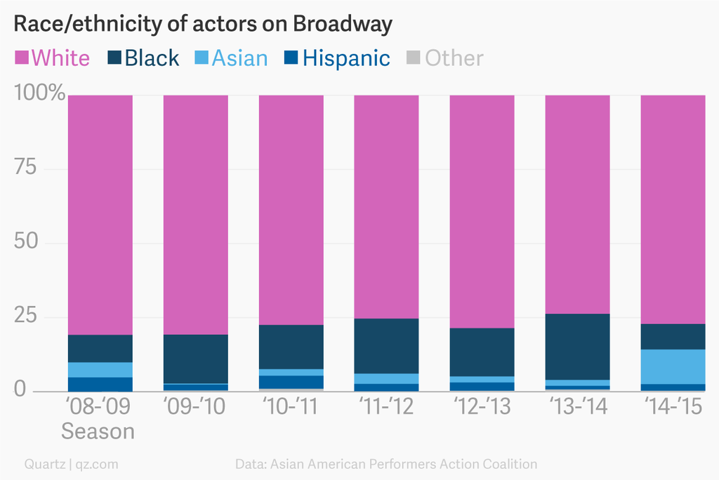

Quarts chart 1

We’ll use ggplot2, dplyr, and the scales package.

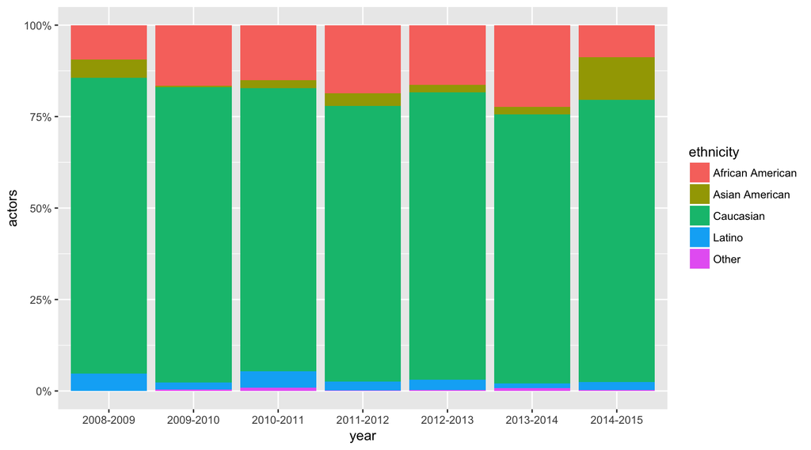

```r
library(ggplot2)
library(scales)
library(dplyr)
ggplot(broadway, aes(x=year, y=actors, fill=ethnicity)) +
  geom_bar(position="fill", stat="identity") +
  scale_y_continuous(labels=percent_format())
```

Close.

We need to reorder and move the legend to the top, as well as add a Title and get rid of X and Y labels.

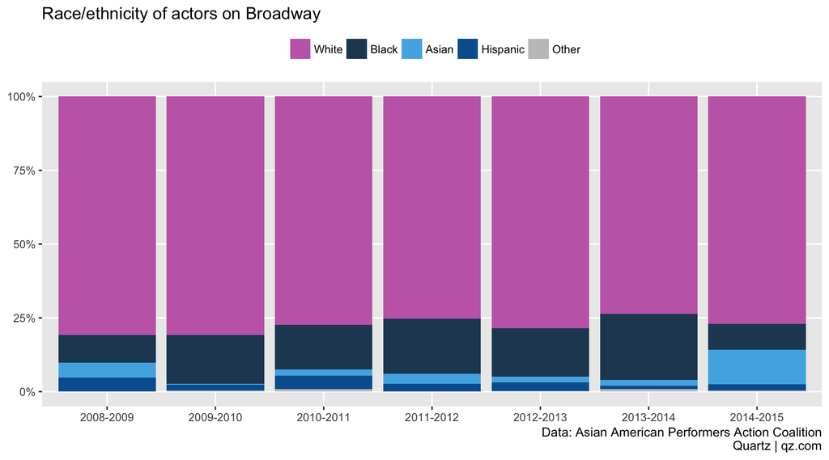

```r
# Rename ethnicities so it matches the chart
broadway$ethnicity <- gsub("African American", "Black", broadway$ethnicity)
broadway$ethnicity <- gsub("Asian American", "Asian", broadway$ethnicity)
broadway$ethnicity <- gsub("Caucasian", "White", broadway$ethnicity)
broadway$ethnicity <- gsub("Latino", "Hispanic", broadway$ethnicity)

broadway$ethnicity <- as.factor(broadway$ethnicity)
#levels(broadway$ethnicity) <- c("White", "Black", "Asian", "Hispanic", "Other")

# Set up the Quartz color palette

qzPalette <- c("#c56bb6", "#244763", "#51b2e5", "#01609f", "#c4c4c4")

ggplot(broadway, aes(x=year, y=actors, fill=factor(ethnicity, levels=c("White", "Black", "Asian", "Hispanic", "Other")))) +
  geom_bar(position="fill", stat="identity") +
  scale_y_continuous(labels=percent_format()) +
  theme(legend.position="top") +
  scale_fill_manual(values=qzPalette) +
  labs(fill="") +
  labs(x=NULL, y=NULL, title="Race/ethnicity of actors on Broadway", subtitle=NULL,
                caption="Data: Asian American Performers Action Coalition\nQuartz | qz.com") +
  theme(panel.border=element_blank()) +
  theme(panel.grid.minor=element_blank())
```

Pretty nice.

Next chart:

[figure not shown]

Second QZ chart

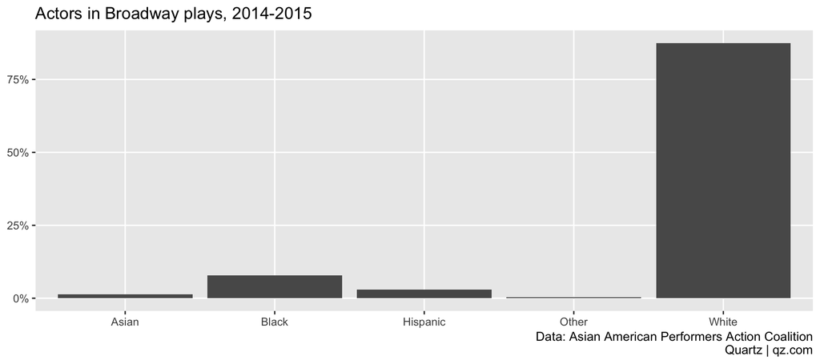

```r
broadway2015_plays <- subset(broadway, year=="2014-2015" & type=="Play")

ggplot(broadway2015_plays, aes(x=ethnicity)) +
  geom_bar(stat="identity", aes(y=actors/sum(actors))) +
  scale_y_continuous(labels=percent_format()) +
  theme(legend.position="top") +
  scale_fill_manual(values=qzPalette) +
  labs(fill="") +
  labs(x=NULL, y=NULL, title="Actors in Broadway plays, 2014-2015", subtitle=NULL,
                caption="Data: Asian American Performers Action Coalition\nQuartz | qz.com") +
  theme(panel.border=element_blank()) +
  theme(panel.grid.minor=element_blank())
```

Alright, we gotta add some more lines of code to format it better. Like flipping the axis sideways and reordering the columns.

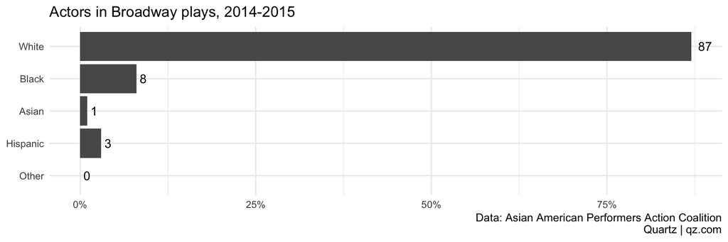

```r
# Need to make a dataframe of percents

broadway2015_play_percent <- broadway2015_plays %>%
  group_by(ethnicity) %>%
  summarise(total=sum(actors)) %>%
  mutate(percent=round(total/sum(total),2))

ggplot(broadway2015_play_percent, aes(x=factor(ethnicity, levels=c("Other", "Hispanic", "Asian", "Black", "White")))) +
  geom_bar(stat="identity", position="dodge", aes(y=percent)) +
  geom_text(aes(y=percent, label=percent*100), hjust=-.5) +
  coord_flip() +
  scale_y_continuous(labels=percent) +
  theme(legend.position="top") +
  labs(fill="") +
  labs(x=NULL, y=NULL, title="Actors in Broadway plays, 2014-2015", subtitle=NULL,
                caption="Data: Asian American Performers Action Coalition\nQuartz | qz.com") +
  theme(panel.border=element_blank()) +
  theme(panel.grid.minor=element_blank()) +
  theme_minimal()
```

Should be easy to tweak the code for the previous code for the Quartz version.

[figure not shown]

Third QZ chart

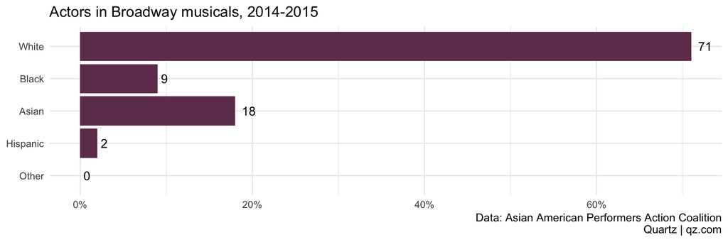

```r
# Need to make a dataframe of percents

broadway2015_musical_percent <- broadway %>%
  filter(year=="2014-2015" & type=="Musical") %>%
  group_by(ethnicity) %>%
  summarise(total=sum(actors)) %>%
  mutate(percent=round(total/sum(total),2))

ggplot(broadway2015_musical_percent, aes(x=factor(ethnicity, levels=c("Other", "Hispanic", "Asian", "Black", "White")))) +
  geom_bar(stat="identity", position="dodge", fill="#703c5c", aes(y=percent)) +
  geom_text(aes(y=percent, label=percent*100), hjust=-.5) +
  coord_flip() +
  scale_y_continuous(labels=percent) +
  guides(fill=F) +
  theme(legend.position="top") +
  labs(fill="") +
  labs(x=NULL, y=NULL, title="Actors in Broadway musicals, 2014-2015", subtitle=NULL,
                caption="Data: Asian American Performers Action Coalition\nQuartz | qz.com") +
  theme(panel.border=element_blank()) +
  theme(panel.grid.minor=element_blank()) +
  theme_minimal()
```

Last chart. It looks complicated.

[figure not shown]

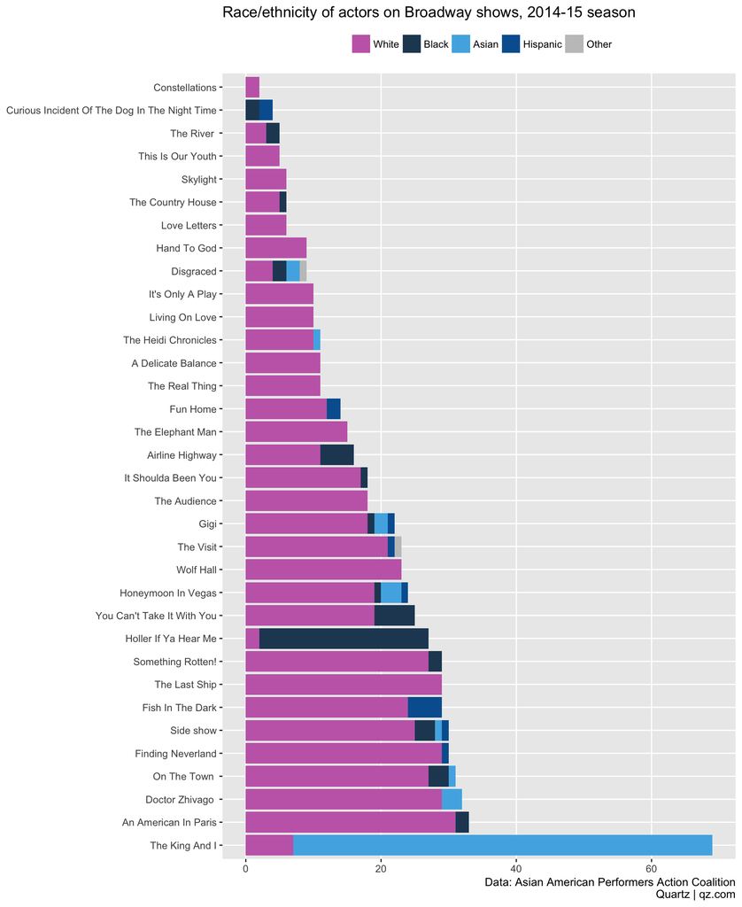

```r
# coord_flip reverses a lot of things, so we have to sort of reverse the order of colors and factors for this to work

qzPalette_reverse <- c("#c4c4c4", "#01609f","#51b2e5","#244763","#c56bb6")

broadway2015 <- filter(broadway, year=="2014-2015") %>%
  group_by(show) %>%
  mutate(total=sum(actors)) %>%
  arrange(total)

broadway2015$show <- factor(broadway2015$show, levels=rev(broadway2015$show))

ggplot(broadway2015, aes(x=show, y=actors, fill=factor(ethnicity, levels=c("Other", "Hispanic", "Asian", "Black", "White")))) +
  geom_bar(stat="identity") +
  coord_flip() +
  theme(legend.position="top") +
  scale_fill_manual(values=qzPalette_reverse) +
  guides(fill = guide_legend(reverse=TRUE)) +
  labs(fill="") +
  labs(x=NULL, y=NULL, title="Race/ethnicity of actors on Broadway shows, 2014-15 season", subtitle=NULL,
                caption="Data: Asian American Performers Action Coalition\nQuartz | qz.com") +
  theme(panel.border=element_blank()) +
  theme(panel.grid.minor=element_blank())
```

Close! We need to get rid of the X axis values and add a colun on the right of total actors.

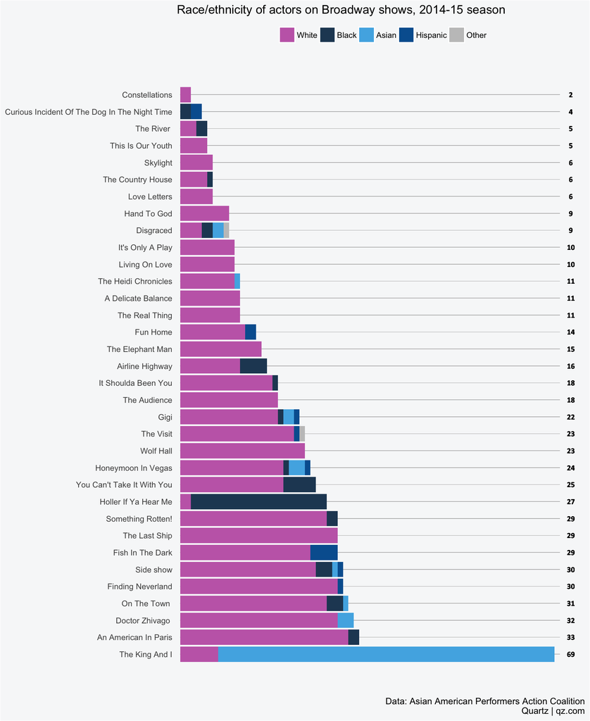

```r
#broadway2015 <- as.data.frame(broadway2015)
broadway2015$show <- factor(broadway2015$show, levels=rev(broadway2015$show))

ggplot(broadway2015, aes(x=show, y=actors, fill=factor(ethnicity, levels=c("Other", "Hispanic", "Asian", "Black", "White")))) +
  geom_segment(data=broadway2015, aes(y=0, yend=70, x=show, xend=show), color="#b2b2b2", size=0.15) +
  geom_bar(stat="identity") +
  coord_flip() +
  theme(legend.position="top") +
  scale_fill_manual(values=qzPalette_reverse) +
  guides(fill = guide_legend(reverse=TRUE)) +
  labs(fill="") +
  labs(x=NULL, y=NULL, title="Race/ethnicity of actors on Broadway shows, 2014-15 season", subtitle=NULL,
                caption="Data: Asian American Performers Action Coalition\nQuartz | qz.com") +
  geom_rect(data=broadway2015, aes(xmin=-Inf, xmax=Inf, ymin=70, ymax=74), fill="#f7f8f9") +
  geom_text(data=broadway2015, aes(label=total, y=72, x=show), fontface="bold", size=3, family="Calibri") +
  geom_text(data=filter(broadway2015, show=="Constellations"), aes(x=show, y=72, label="Cast members"),
                     color="#7a7d7e", size=3.1, vjust=-10, fontface="bold", family="Calibri") +
  scale_x_discrete(expand=c(0.05,0)) +
  scale_y_discrete(limits=c(0,74)) +
  theme(panel.grid.minor=element_blank()) +
    theme(panel.grid.major=element_blank()) +

  theme(panel.border=element_blank()) +
  theme(axis.ticks=element_blank()) +
  theme(axis.text.x=element_blank()) +
  theme(axis.ticks.y=element_blank()) +
  theme(plot.background = element_rect(fill = "#f7f8f9")) +
  theme(panel.background = element_rect(fill = "#f7f8f9",
                                colour = "#f7f8f9",
                                size = 0.5),
        legend.background = element_rect(fill = "#f7f8f9"))
```

Alright, we’ve done a lot with bar charts.

Let’s move on to

## Line charts

We’ll use **datapasta** to copy and paste Hamilton attendance and proceeds data into RStudio from the [Internet Broadway Database](https://www.ibdb.com/grosses-production/hamilton-499521).

Be sure you’ve already installed the **datapasta** and **tibble** packages. Revisit the walkthrough if you need to.

```r
library(tibble)

## Bring the data from Hamilton's 2016-2017 season and call it Ham1

Ham1 <- tribble(
            ~Week.Ending,       ~Gross, ~X..Gross.Pot., ~Attendance, ~X..Capacity, ~X..Previews, ~X..Perf.,
          "Jan 22, 2017", "$2,451,721",         "104%",    "10,754",       "102%",            0,         8,
          "Jan 15, 2017", "$2,451,260",         "103%",    "10,756",       "102%",            0,         8,
           "Jan 8, 2017", "$2,456,491",         "103%",    "10,754",       "102%",            0,         8,
           "Jan 1, 2017", "$3,335,430",         "106%",    "10,755",       "102%",            0,         8,
          "Dec 25, 2016", "$3,303,538",         "105%",    "10,755",       "102%",            0,         8,
          "Dec 18, 2016", "$2,240,488",         "103%",    "10,738",       "102%",            0,         8,
          "Dec 11, 2016", "$2,443,438",         "103%",    "10,753",       "102%",            0,         8,
           "Dec 4, 2016", "$2,233,259",         "103%",    "10,732",       "102%",            0,         8,
          "Nov 27, 2016", "$3,260,089",         "103%",    "10,752",       "102%",            0,         8,
          "Nov 20, 2016", "$2,454,656",         "126%",    "10,752",       "102%",            0,         8,
          "Nov 13, 2016", "$2,452,746",         "126%",    "10,756",       "102%",            0,         8,
           "Nov 6, 2016", "$2,227,546",         "115%",    "10,732",       "102%",            0,         8,
          "Oct 30, 2016", "$2,215,641",         "114%",    "10,754",       "102%",            0,         8,
          "Oct 23, 2016", "$1,993,088",         "103%",    "10,733",       "102%",            0,         8,
          "Oct 16, 2016", "$2,163,855",         "111%",    "10,754",       "102%",            0,         8,
           "Oct 9, 2016", "$2,214,118",         "114%",    "10,755",       "102%",            0,         8,
           "Oct 2, 2016", "$2,174,750",         "112%",    "10,754",       "102%",            0,         8,
          "Sep 25, 2016", "$2,419,442",         "111%",    "12,100",       "102%",            0,         9,
          "Sep 18, 2016", "$2,159,038",         "111%",    "10,755",       "102%",            0,         8,
          "Sep 11, 2016", "$2,150,229",         "111%",    "10,753",       "102%",            0,         8,
           "Sep 4, 2016", "$2,091,791",         "108%",    "10,752",       "102%",            0,         8,
          "Aug 28, 2016", "$2,054,058",         "106%",    "10,753",       "102%",            0,         8,
          "Aug 21, 2016", "$2,065,377",         "106%",    "10,753",       "102%",            0,         8,
          "Aug 14, 2016", "$2,045,095",         "105%",    "10,756",       "102%",            0,         8,
           "Aug 7, 2016", "$2,062,862",         "106%",    "10,756",       "102%",            0,         8,
          "Jul 31, 2016", "$2,041,865",         "105%",    "10,755",       "102%",            0,         8,
          "Jul 24, 2016", "$2,046,711",         "105%",    "10,754",       "102%",            0,         8,
          "Jul 17, 2016", "$2,282,207",         "104%",    "12,053",       "101%",            0,         9,
          "Jul 10, 2016", "$2,053,263",         "106%",    "10,753",       "102%",            0,         8,
           "Jul 3, 2016", "$2,022,790",         "104%",    "10,739",       "102%",            0,         8,
          "Jun 26, 2016", "$2,007,222",         "103%",    "10,732",       "102%",            0,         8,
          "Jun 19, 2016", "$2,026,838",         "122%",    "10,752",       "102%",            0,         8,
          "Jun 12, 2016", "$2,028,208",         "152%",    "10,754",       "102%",            0,         8,
           "Jun 5, 2016", "$1,854,989",         "139%",    "10,756",       "102%",            0,         8,
          "May 29, 2016", "$1,917,923",         "144%",    "10,752",       "102%",            0,         8
          )

# Then go to the link for 2015-2016 data at the bottom and bring that data in as Ham2

Ham2 <- tribble(
            ~Week.Ending,       ~Gross, ~X..Gross.Pot., ~Attendance, ~X..Capacity, ~X..Previews, ~X..Perf.,
          "May 22, 2016", "$1,764,808",         "132%",    "10,755",       "102%",            0,         8,
          "May 15, 2016", "$1,686,168",         "126%",    "10,736",       "102%",            0,         8,
           "May 8, 2016", "$1,833,473",         "137%",    "10,754",       "102%",            0,         8,
           "May 1, 2016", "$1,818,758",         "136%",    "10,754",       "102%",            0,         8,
          "Apr 24, 2016", "$1,813,024",         "136%",    "10,753",       "102%",            0,         8,
          "Apr 17, 2016", "$1,678,620",         "126%",    "10,732",       "102%",            0,         8,
          "Apr 10, 2016", "$1,813,655",         "136%",    "10,754",       "102%",            0,         8,
           "Apr 3, 2016", "$1,822,594",         "137%",    "10,752",       "102%",            0,         8,
          "Mar 27, 2016", "$1,719,570",         "129%",    "10,755",       "102%",            0,         8,
          "Mar 20, 2016", "$1,740,104",         "130%",    "10,753",       "102%",            0,         8,
          "Mar 13, 2016", "$1,758,555",         "132%",    "10,756",       "102%",            0,         8,
           "Mar 6, 2016", "$1,766,223",         "132%",    "10,751",       "102%",            0,         8,
          "Feb 28, 2016", "$1,755,010",         "131%",    "10,756",       "102%",            0,         8,
          "Feb 21, 2016", "$1,750,924",         "131%",    "10,756",       "102%",            0,         8,
          "Feb 14, 2016", "$1,792,099",         "134%",    "10,751",       "102%",            0,         8,
           "Feb 7, 2016", "$1,771,086",         "133%",    "10,746",       "102%",            0,         8,
          "Jan 31, 2016", "$1,732,653",         "130%",    "10,748",       "102%",            0,         8,
          "Jan 24, 2016", "$1,304,793",         "130%",     "8,062",       "102%",            0,         6,
          "Jan 17, 2016", "$1,769,360",         "133%",    "10,753",       "102%",            0,         8,
          "Jan 10, 2016", "$1,712,792",         "128%",    "10,757",       "102%",            0,         8,
           "Jan 3, 2016", "$1,959,785",         "147%",    "10,745",       "102%",            0,         8,
          "Dec 27, 2015", "$1,844,837",         "138%",    "10,747",       "102%",            0,         8,
          "Dec 20, 2015", "$1,658,598",         "124%",    "10,728",       "102%",            0,         8,
          "Dec 13, 2015", "$1,639,634",         "123%",    "10,727",       "102%",            0,         8,
           "Dec 6, 2015", "$1,613,691",         "121%",    "10,732",       "102%",            0,         8,
          "Nov 29, 2015", "$1,833,886",         "137%",    "10,739",       "102%",            0,         8,
          "Nov 22, 2015", "$1,450,763",         "109%",    "10,735",       "102%",            0,         8,
          "Nov 15, 2015", "$1,596,311",         "120%",    "10,738",       "102%",            0,         8,
           "Nov 8, 2015", "$1,772,253",         "118%",    "12,050",       "101%",            0,         9,
           "Nov 1, 2015", "$1,595,089",         "119%",    "10,726",       "101%",            0,         8,
          "Oct 25, 2015", "$1,489,233",         "112%",    "10,708",       "101%",            0,         8,
          "Oct 18, 2015", "$1,478,877",         "111%",    "10,721",       "101%",            0,         8,
          "Oct 11, 2015", "$1,678,091",         "126%",    "10,717",       "101%",            0,         8,
           "Oct 4, 2015", "$1,481,172",         "111%",    "10,705",       "101%",            0,         8,
          "Sep 27, 2015", "$1,567,451",         "117%",    "10,712",       "101%",            0,         8,
          "Sep 20, 2015", "$1,545,346",         "116%",    "10,688",       "101%",            0,         8,
          "Sep 13, 2015", "$1,561,640",         "117%",    "10,703",       "101%",            0,         8,
           "Sep 6, 2015", "$1,697,070",         "127%",    "10,706",       "101%",            0,         8,
          "Aug 30, 2015", "$1,548,928",         "116%",    "10,710",       "101%",            0,         8,
          "Aug 23, 2015", "$1,456,753",         "109%",    "10,708",       "101%",            0,         8,
          "Aug 16, 2015", "$1,459,314",         "109%",    "10,706",       "101%",            0,         8,
           "Aug 9, 2015", "$1,255,163",          "94%",    "10,638",       "101%",            4,         4,
           "Aug 2, 2015", "$1,490,816",         "112%",    "10,619",       "100%",            8,         0,
          "Jul 26, 2015", "$1,302,511",         "112%",     "9,290",       "100%",            7,         0,
          "Jul 19, 2015", "$1,288,436",         "110%",     "9,273",       "100%",            7,         0
          )

# Bind the two together.

ham <- rbind(Ham1,Ham2)
```

## We need to clean up the data

```r
# Start with the column names

colnames(ham) <- c("week", "gross", "potential", "attendance", "capacity", "previews", "performances")

# Let's strip out the characters like "$", ",", and "%" so we can make the columns numbers

ham$gross <- gsub("\\$", "", ham$gross)
ham$gross <- gsub(",", "", ham$gross)
ham$gross <- as.numeric(ham$gross)

ham$potential <- gsub("%", "", ham$potential)
ham$potential <- as.numeric(ham$potential)

ham$attendance <- gsub(",", "", ham$attendance)
ham$attendance <- as.numeric(ham$attendance)

ham$capacity <- gsub("%", "", ham$capacity)
ham$capacity <- as.numeric(ham$capacity)

library(DT)
datatable(ham)
```

|  | week | gross | potential | attendance | capacity | previews | performances |
| --- | --- | --- | --- | --- | --- | --- | --- |
| 1 | Jan 22, 2017 | 2451721 | 104 | 10754 | 102 | 0 | 8 |
| 2 | Jan 15, 2017 | 2451260 | 103 | 10756 | 102 | 0 | 8 |
| 3 | Jan 8, 2017 | 2456491 | 103 | 10754 | 102 | 0 | 8 |
| 4 | Jan 1, 2017 | 3335430 | 106 | 10755 | 102 | 0 | 8 |
| 5 | Dec 25, 2016 | 3303538 | 105 | 10755 | 102 | 0 | 8 |
| 6 | Dec 18, 2016 | 2240488 | 103 | 10738 | 102 | 0 | 8 |
| 7 | Dec 11, 2016 | 2443438 | 103 | 10753 | 102 | 0 | 8 |
| 8 | Dec 4, 2016 | 2233259 | 103 | 10732 | 102 | 0 | 8 |
| 9 | Nov 27, 2016 | 3260089 | 103 | 10752 | 102 | 0 | 8 |
| 10 | Nov 20, 2016 | 2454656 | 126 | 10752 | 102 | 0 | 8 |

[output cut: 70 more lines]

Looks pretty good.

Now let’s visualize.

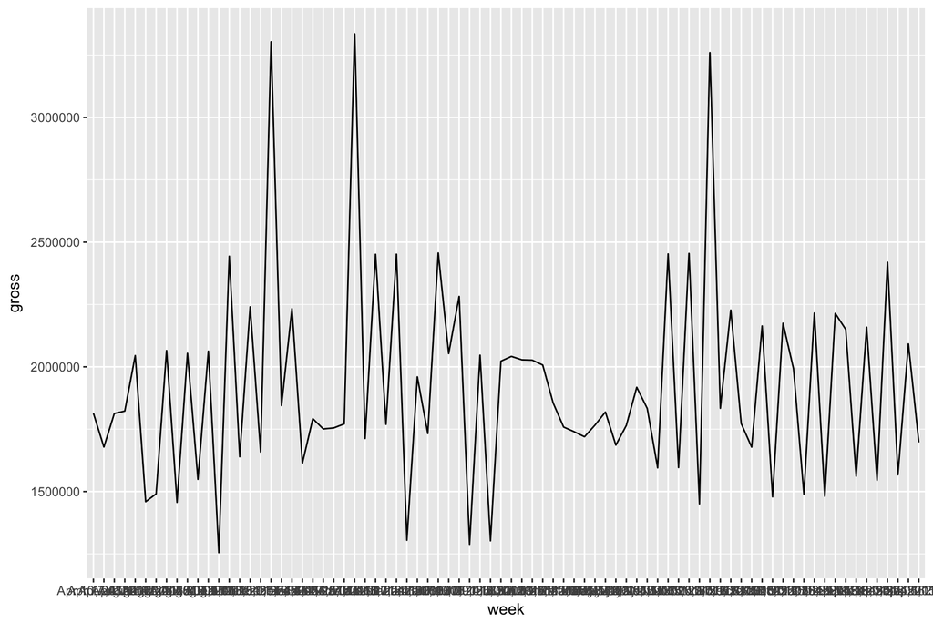

```r
ggplot(ham, aes(x=week, y=gross, group=1)) + geom_line()
```

That doesn’t look right.

What’s going on?

Check a look at the cluster in the x axis. It’s listing it alphabetically.

We need to fix the dates.

We’ll use the package **lubridate**

```r
# Also, let's add another column with clean dates in the data column

library(lubridate)
```

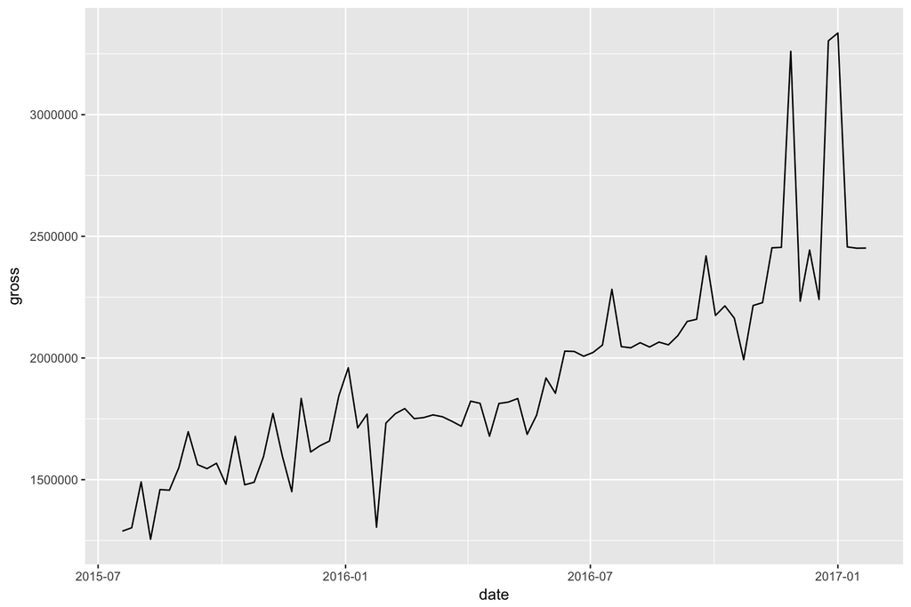

```r
ham$date <- mdy(ham$week)
ggplot(ham, aes(x=date, y=gross, group=1)) + geom_line()
```

```r
annotate("text", x = 4, y = 25, label = "Some text")
```

```
## mapping: x = x, y = y
## geom_text: na.rm = FALSE
## stat_identity: na.rm = FALSE
## position_identity
```

This makes way more sense now.